# PhillyStat360 — Violation Tier Mapping

VacancyGuide2026 Verification & Complete Building Tier Reference

Zhe Fang

2026-02-19

# 0. Purpose

This document builds the **complete violation tier mapping** for the PhillyStat360 building model. It replaces the earlier `violation_tier_mapping.xlsx` which contained only a partial subset of codes.

**Why this matters:** The current VPI model scores violations on a 3-tier system (+1, +2, +3 points). To engineer violation-based features for our ML model, we need the exact code lists. Getting this wrong means our features won’t align with the system we’re trying to improve.

# 1. Source of Truth: VacancyGuide2026 Building Violation Tiers

The VacancyGuide2026.pdf (received from Taylor Popp, Feb 5 2026) defines three violation tiers for the **building model** on pages 6–7. Each tier is specified as a SQL `IN (...)` clause with an exact list of violation codes.

Key rules from the guide (p.7, footnote 2):

- Only violations with `violationstatus = 'OPEN'` count
- Only violations that are `"current"` count (i.e., the inspection occurred more recently than the most recent construction or demolition)
- **Only the highest applicable tier is scored per property** — not cumulative across tiers

We now transcribe these code lists verbatim from the PDF.

```r
# ============================================================
# VacancyGuide2026.pdf, page 6–7: VACANT BUILDING INDICATORS
# Transcribed directly from the SQL IN() clauses
# ============================================================

# Level 1: Add one (1) to Vacant Building Score
# Source: VacancyGuide p.6, first L+I Violations bullet
guide_level1 <- c(
  "PM15-304.10",   # EXTERIOR STRUCT STAIRS, ETC
  "PM15-304.11",   # EXTERIOR STRUCT CHIM TOWERS
  "PM15-304.19",   # DOOR AND WINDOW OCCUPIED/MIXED
  "PM15-304.19O",  # DOOR AND WINDOW OCCUPIED/MIXED
  "PM15-304.2",    # EXTERIOR STRUCT PROTECTIVE TRE
  "PM15-304.8",    # EXTERIOR STRUCT DEC FEATURES
  "PM15-308.1",    # RUBBISH AND GARBAGE
  "PM15-309.1",    # PEST ELIMINATION INFESTATION
  "PM15-309.3",    # PEST ELIM INFEST SGLE OCCUP
  "PM15-309.4",    # PEST ELIMINATION INFESTATION
  "PM-302.2/1",    # EXT A-CLEAN/EXTERMINATE
  "PM-302.2/2",    # EXT A-CLEAN RUBBISH/GARBAGE
  "PM-302.3/1",    # EXT A-CLEAN WEEDS/PLANTS
  "PM-302.4/6",    # DRAINAGE-DOWNSPOUT CONNECT
  "PM-302.4/7",    # DRAINAGE-DOWNSPOUT REPR/REPLC
  "PM-304.1/1",    # EXT S-EXTERIOR REPAIR/MAINTAIN
  "PM-304.6/1",    # EXT S-CHIMMEYS/TOWERS MAINTAIN
  "PM-304.8/1",    # EXT S-WINDOW REPAIR/MAINTAIN
  "PM-304.8/15",   # EXT S-DOOR WEATHERTIGHT
  "PM-304.8/16",   # EXT S-WINDOW REPAIR/REPLACE
  "PM-304.8/17",   # EXT S-DOOR REPAIR/REPLACE
  "PM-304.8/18",   # EXT S-DOORFRAME REPAIR/REPLACE
  "PM-304.8/19",   # EXT S-WINDOW/FRAME RODENTPROOF
  "PM-304.8/2",    # EXT S-DOORS MAINTAIN
  "PM-304.8/20",   # EXT S-DOORS/FRAMES RODENTPROOF
  "PM-304.8/21"    # MIX USE PROP REPLAC W/D 80%
)

# Level 2: Add two (2) to Vacant Building Score
# Source: VacancyGuide p.7, second L+I Violations bullet
guide_level2 <- c(
  "PM15-110.7",    # ID WORK SCHEDULE REQ
  "PM15-302.1",    # EXTERIOR AREA SANITATION
  "PM15-302.4",    # EXTERIOR AREA WEEDS
  "PM15-302.5",    # EXTERIOR AREA RODENT HARBORAGE
  "PM15-304.13",   # EXTERIOR STRUCTURE WINDOWS
  "PM15-304.15",   # EXTERIOR STRUCTURE DOORS
  "PM15-304.16",   # EXTERIOR STRUCTURE HATCHWAY
  "PM15-304.4",    # EXTERIOR STRUCT STRUCTURAL MEM
  "PM15-304.5",    # EXTERIOR STRUCTURE FOUNDATIONS
  "PM15-304.6",    # EXTERIOR STRUCTURE WALLS
  "PM15-304.7",    # EXTERIOR STRUCT ROOF DRAINAGE
  "PM-304.2/1",    # EXT S-FOUNDATION WALLS, MAINTA
  "PM-304.3/1",    # EXT S-WALLS REPAIR/MAINTAIN
  "PM-304.3/2",    # EXT S-WALLS MAKE WEATHERTIGHT
  "PM-304.3/3",    # EXT S-WALLS REPAIR BULGING
  "PM-304.3/4",    # EXT S-WALLS REPAIR CRACKS
  "PM-304.3/5",    # EXT S-WALLS REPAIR STUCCO
  "PM-304.5/2",    # EXT S-EXPOSED SURFACES MAINTAI
  "PM-304.5/3"     # EXT S-CORNICE BARGEBOARD DEFEC
)

# Level 3: Add three (3) to Vacant Building Score
# Source: VacancyGuide p.7, third L+I Violations bullet
guide_level3 <- c(
  "9-3905",        # VACANT STRUCTURE LICENSE
  "CP-103",        # LICENSE - VACANT BUILDING
  "PM-102.4/2",    # LICENSE-VAC RES BLDG
  "PM-102.4/4",    # LICENSE-VAC COMM BLDG
  "PM15-108.1",    # UNSAFE STRUCTURE
  "PM15-108.2",    # VACANT AND OPEN
  "PM15-109.1",    # UNFIT STRUCTURE
  "PM15-110.1",    # ID STRUCTURE
  "PM15-301",      # VACANT STRUCTURE AND LAND
  "PM15-304.1",    # EXTERIOR STRUCTURALLY UNSAFE
  "PM15-304.19V",  # DOOR AND WINDOW VACANT
  "PM15-304.1A",   # EXTERIOR STRUCT UNSAFE COND 1
  "PM15-304.1B",   # EXTERIOR STRUCT UNSAFE COND 2
  "PM15-304.1C",   # EXTERIOR STRUCT UNSAFE COND 3
  "PM15-304.1D",   # EXTERIOR STRUCT UNSAFE COND 4
  "PM15-304.1E",   # EXTERIOR STRUCT UNSAFE COND 5
  "PM15-304.1F",   # EXTERIOR STRUCT UNSAFE COND 6
  "PM15-304.1G",   # EXTERIOR STRUCT UNSAFE COND 7
  "PM15-304.1H",   # EXTERIOR STRUCT UNSAFE COND 8
  "PM15-304.1I",   # EXTERIOR STRUCT UNSAFE COND 9
  "PM15-304.1J",   # EXTERIOR STRUCT UNSAFE COND 10
  "PM15-901.1",    # VACANT PROPERTIES-GENERAL
  "PM15-901.2",    # VACANT PROP-BLIGHTED COND
  "PM15-902.1",    # LARGE VACANT PROP-OPENINGS
  "PM-304.4/1",    # EXT S-ROOF REPAIR
  "PM-306.0/1",    # VACANT PROP STANDARD
  "PM-306.0/90",   # VACANT BLDG KEEP CLEAN GET LIC
  "PM-306.2/1",    # VACANT BLDG UNSECURED COUNT
  "PM-306.2/4",    # VAC PROP REPLAC WIN/DRS 80%
  "PM-306.2/90",   # VACANT BLDG - VOTA
  "PM-306.2/91",   # CP VAC PROP REPLAC WIN/DRS 80%
  "PM-306.2/92",   # VAC PROP REPLAC WIN/DRS 80% CP
  "PM-307.1/1",    # VACANT PROP UNSAFE
  "PM-307.1/11",   # WALL DETERIORATION
  "PM-307.1/12",   # WALL PARTIALLY COLLAPSED
  "PM-307.1/13",   # WALL FIRE DAMAGED
  "PM-307.1/19",   # VACANT BLDG UNSEC/UNSAFE CSU
  "PM-307.1/2",    # ROOF DETERIORATION
  "PM-307.1/3",    # ROOF PARTIALLY COLLAPSED
  "PM-307.1/4",    # ROOF FIRE DAMAGED
  "PM-307.1/5",    # F/C DETERIORATED
  "PM-307.1/6",    # FLOOR/CEILING PARTIALLY COLL
  "PM-307.1/7",    # FLOOR/CEILING FIRE DAMAGED
  "PM-307.1/8",    # WALL BULGED
  "PM-307.1/9",    # WALL FRACTURED
  "PM-307.1/90",   # VACANT BLDG - UNSAFE
  "PM-307.2/1",    # VACANT PROP UNSAFE EQUIPMENT
  "PM-307.3/1",    # UNFIT PROP STANDARD
  "PM-307.3/2",    # UNFIT PROP CEASED
  "PM-307.3/90",   # UNSAFE - UNFIT NO EVAC
  "PM-307.3/91",   # UNSAFE - UNFIT RELOCATE
  "PM-308.1/1",    # ROOF DETERIORATED ID
  "PM-308.1/10",   # WALL DETERIORATED IDF
  "PM-308.1/11",   # WALL PARTIALLY COLLAPSED ID
  "PM-308.1/12",   # WALL FIRE DAMAGED ID
  "PM-308.1/2",    # ROOF PARTIALLY COLLAPSED ID
  "PM-308.1/3",    # ROOF FIRE DAMAGED ID
  "PM-308.1/4",    # F/C DETERIORATED ID COLLAPSE
  "PM-308.1/5",    # FLOOR/CEILING PARTIALLY C ID
  "PM-308.1/6",    # FLOOR/CEILING FIRE DAMAGED ID
  "PM-308.1/7",    # WALL BULGED ID
  "PM-308.1/8",    # WALL CRACK/FRACT ID
  "PM-308.1/9"     # WALL LOOSE/MISS BRICKS ID
)

# Also from VacancyGuide p.5: VACANT LAND violation codes
# These are separate from the building model
guide_land <- c(
  "CP-102",        # LICENSE - VACANT LOT
  "PM-102.4/1",    # LICENSE-VAC LOT
  "PM-102.4/3",    # LICENSE-VAC WHARF/PIER
  "PM-302.2/4",    # EXT A-VACANT LOT CLEAN/MAINTAI
  "PM-304.9/2",    # PIER-VACANT FAULTY/NO BARRIER
  "PM-304.9/3",    # PIER-VACANT POST SIGNS
  "PM-304.9/4",    # PIER-VACANT OBTAIN LICENSE
  "PM-306.0/2",    # VACANT LOT STANDARD
  "PM-306.0/91"    # VACANT LOT KEEP CLEAN GET LIC
)

cat("=== VacancyGuide Building Code Counts ===\n")
```

```
## === VacancyGuide Building Code Counts ===
```

```r
cat("Level 1 (+1 point):", length(guide_level1), "codes\n")
```

```
## Level 1 (+1 point): 26 codes
```

```r
cat("Level 2 (+2 points):", length(guide_level2), "codes\n")
```

```
## Level 2 (+2 points): 19 codes
```

```r
cat("Level 3 (+3 points):", length(guide_level3), "codes\n")
```

```
## Level 3 (+3 points): 63 codes
```

```r
cat("Building total:     ", length(guide_level1) + length(guide_level2) + length(guide_level3), "codes\n")
```

```
## Building total:      108 codes
```

```r
cat("\nLand violations:    ", length(guide_land), "codes\n")
```

```
##
## Land violations:     9 codes
```

```r
cat("Grand total:        ", length(guide_level1) + length(guide_level2) + length(guide_level3) + length(guide_land), "codes\n")
```

```
## Grand total:         117 codes
```

```r
# Verify no duplicates across building tiers
building_all <- c(guide_level1, guide_level2, guide_level3)
stopifnot("Duplicate codes across building tiers!" = length(building_all) == length(unique(building_all)))
cat("\n✓ No duplicate codes across building tiers\n")
```

```
##
## ✓ No duplicate codes across building tiers
```

```r
# Check overlap between building and land
bldg_land_overlap <- intersect(building_all, guide_land)
cat("Building-Land overlap:", length(bldg_land_overlap), "codes\n")
```

```
## Building-Land overlap: 0 codes
```

```r
if (length(bldg_land_overlap) > 0) cat("  ", paste(bldg_land_overlap, collapse = ", "), "\n")
```

**Key observation:** The VacancyGuide uses **108 codes** for the building model alone. These are not all “vacancy” codes — many are general building maintenance codes (rubbish, windows, drainage) that the city’s model treats as indirect vacancy signals.

# 2. Our Previous Approach: The 54 “Vacancy” Codes

In `00_data_inventory.Rmd`, we identified 54 violation codes from `VIOLATION_DEFINITION.csv` where the title or definition contains the word “vacant.”

```r
violation_def <- read_csv("../rawdata/VIOLATION_DEFINITION.csv", show_col_types = FALSE) %>%
  janitor::clean_names()

our_54 <- violation_def %>%
  filter(str_detect(tolower(violation_code_title), "vacant") |
         str_detect(tolower(violation_definition), "vacant")) %>%
  pull(violation_code)

cat("Codes found by searching 'vacant' in title/definition:", length(our_54), "\n")
```

```
## Codes found by searching 'vacant' in title/definition: 54
```

# 3. The Gap: Cross-Comparison

This is the critical analysis. How much overlap is there between the VacancyGuide’s 108 building codes and our keyword-based 54 codes?

```r
overlap     <- intersect(building_all, our_54)
in_guide_not_54 <- setdiff(building_all, our_54)
in_54_not_guide <- setdiff(our_54, building_all)

cat("=== Cross-Comparison ===\n\n")
```

```
## === Cross-Comparison ===
```

```r
cat("In BOTH VacancyGuide building tiers AND our 54:", length(overlap), "\n")
```

```
## In BOTH VacancyGuide building tiers AND our 54: 23
```

```r
cat("In VacancyGuide but NOT in our 54:             ", length(in_guide_not_54), "\n")
```

```
## In VacancyGuide but NOT in our 54:              85
```

```r
cat("In our 54 but NOT in VacancyGuide building:    ", length(in_54_not_guide), "\n")
```

```
## In our 54 but NOT in VacancyGuide building:     31
```

### 3a. Codes in VacancyGuide but Missing from Our 54

These are the codes we would have **missed entirely** if we only used our 54-code list for feature engineering. They are mostly general building maintenance codes — the word “vacant” does not appear in their title or definition.

```r
# For each missing code, show which tier it belongs to and its title
guide_only_df <- tibble(code = in_guide_not_54) %>%
  mutate(
    tier = case_when(
      code %in% guide_level1 ~ "Level 1 (+1)",
      code %in% guide_level2 ~ "Level 2 (+2)",
      code %in% guide_level3 ~ "Level 3 (+3)"
    )
  ) %>%
  left_join(
    violation_def %>% select(violation_code, violation_code_title),
    by = c("code" = "violation_code")
  ) %>%
  arrange(tier, code)

guide_only_df %>%
  kable(col.names = c("Code", "VacancyGuide Tier", "Title (from VIOLATION_DEFINITION)"),
        caption = paste0(length(in_guide_not_54),
                         " codes in VacancyGuide building tiers but NOT in our 54 'vacancy' codes")) %>%
  kable_styling(bootstrap_options = c("striped", "condensed"), full_width = FALSE, font_size = 12) %>%
  row_spec(which(guide_only_df$tier == "Level 1 (+1)"), background = "#FFF9C4") %>%
  row_spec(which(guide_only_df$tier == "Level 2 (+2)"), background = "#FFE0B2") %>%
  row_spec(which(guide_only_df$tier == "Level 3 (+3)"), background = "#FFCDD2")
```

85 codes in VacancyGuide building tiers but NOT in our 54 ‘vacancy’ codes

| Code | VacancyGuide Tier | Title (from VIOLATION_DEFINITION) |
| --- | --- | --- |
| PM-302.2/1 | Level 1 (+1) | EXT A-CLEAN/EXTERMINATE |
| PM-302.2/2 | Level 1 (+1) | EXT A-CLEAN RUBBISH/GARBAGE |
| PM-302.3/1 | Level 1 (+1) | EXT A-CLEAN WEEDS/PLANTS |
| PM-302.4/6 | Level 1 (+1) | DRAINAGE-DOWNSPOUT CONNECT |
| PM-302.4/7 | Level 1 (+1) | DRAINAGE-DOWNSPOUT REPR/REPLC |
| PM-304.1/1 | Level 1 (+1) | EXT S-EXTERIOR REPAIR/MAINTAIN |
| PM-304.6/1 | Level 1 (+1) | EXT S-CHIMMEYS/TOWERS MAINTAIN |
| PM-304.8/1 | Level 1 (+1) | EXT S-WINDOW REPAIR/MAINTAIN |
| PM-304.8/15 | Level 1 (+1) | EXT S-DOOR WEATHERTIGHT |
| PM-304.8/16 | Level 1 (+1) | EXT S-WINDOW REPAIR/REPLACE |
| PM-304.8/17 | Level 1 (+1) | EXT S-DOOR REPAIR/REPLACE |
| PM-304.8/18 | Level 1 (+1) | EXT S-DOORFRAME REPAIR/REPLACE |
| PM-304.8/19 | Level 1 (+1) | EXT S-WINDOW/FRAME RODENTPROOF |
| PM-304.8/2 | Level 1 (+1) | EXT S-DOORS MAINTAIN |
| PM-304.8/20 | Level 1 (+1) | EXT S-DOORS/FRAMES RODENTPROOF |
| PM-304.8/21 | Level 1 (+1) | MIX USE PROP REPLAC W/D 80% |
| PM15-304.10 | Level 1 (+1) | EXTERIOR STRUCTURE STAIRS, DECKS, PORCHES |
| PM15-304.11 | Level 1 (+1) | EXTERIOR STRUCTURE CHIMNEYS TOWERS |
| PM15-304.19 | Level 1 (+1) | DOOR AND WINDOW OCCUPIED/MIXED |
| PM15-304.19O | Level 1 (+1) | DOOR AND WINDOW OCCUPIED/MIXED |
| PM15-304.2 | Level 1 (+1) | EXTERIOR STRUCTURE PROTECTIVE TREATMENT |
| PM15-304.8 | Level 1 (+1) | EXTERIOR STRUCTURE DECORATIVE FEATURES |
| PM15-308.1 | Level 1 (+1) | RUBBISH & GARBAGE |
| PM15-309.1 | Level 1 (+1) | PEST ELIMINATION INFESTATION |
| PM15-309.3 | Level 1 (+1) | PEST ELIMINATION INFESTATION SINGLE OCCUPANT |
| PM15-309.4 | Level 1 (+1) | PEST ELIMINATION INFESTATION |
| PM-304.2/1 | Level 2 (+2) | EXT S-FOUNDATION WALLS, MAINTA |
| PM-304.3/1 | Level 2 (+2) | EXT S-WALLS REPAIR/MAINTAIN |
| PM-304.3/2 | Level 2 (+2) | EXT S-WALLS MAKE WEATHERTIGHT |
| PM-304.3/3 | Level 2 (+2) | EXT S-WALLS REPAIR BULGING |

[output cut: 55 more lines]

**Why this gap exists:** Our 54-code list was built by text-searching for “vacant” in violation titles/definitions. But VacancyGuide Level 1 and Level 2 are almost entirely made up of general property maintenance codes (rubbish, drainage, window repair, pest control, etc.) — they don’t contain the word “vacant” because they can occur at any property. The city’s model includes them because L&I observed that these violations *tend to cluster on properties trending toward vacancy*, even though they also occur at occupied properties.

### 3b. Our 54 Codes Not in VacancyGuide Building Tiers

These codes contain “vacant” in their title but are NOT used in the VacancyGuide building model. Why?

```r
our_only_df <- tibble(code = in_54_not_guide) %>%
  left_join(
    violation_def %>% select(violation_code, violation_code_title),
    by = c("code" = "violation_code")
  ) %>%
  mutate(
    likely_reason = case_when(
      code %in% guide_land ~ "Used in LAND model, not building",
      str_detect(tolower(violation_code_title), "lot") ~ "Land/lot-specific code",
      str_detect(code, "^F-|^FC-") ~ "Fire safety code — not in VacancyGuide scoring",
      str_detect(code, "9-3904") ~ "Vacant LOT license (land model)",
      str_detect(code, "9-3906|9-3907") ~ "Waterfront/managing agent — not in scoring",
      str_detect(code, "PM15-902") ~ "Large vacant property sub-codes (902.3, 902.7 not scored)",
      TRUE ~ "Review needed"
    )
  ) %>%
  arrange(code)

our_only_df %>%
  kable(col.names = c("Code", "Title", "Likely Reason Not in Building Tiers"),
        caption = paste0(length(in_54_not_guide),
                         " codes in our 54 but NOT in VacancyGuide building tiers")) %>%
  kable_styling(bootstrap_options = c("striped", "condensed"), full_width = FALSE, font_size = 12)
```

31 codes in our 54 but NOT in VacancyGuide building tiers

| Code | Title | Likely Reason Not in Building Tiers |
| --- | --- | --- |
| 10-715 | LITTER ON VACANT LOTS | Land/lot-specific code |
| 6-Sep | VACANT WATERFRONT STRUCTURE | Review needed |
| 7-Sep | MANAGING AGENT REQUIRED | Review needed |
| 9-3904 | VACANT LOT LICENSE | Land/lot-specific code |
| 9-3906 | VACANT WATERFRONT STRUCTURE | Waterfront/managing agent — not in scoring |
| 9-3906 (2)(A) | VACANT WATERFRONT STRUCTURE FAILURE TO PROVIDE BARRIER | Waterfront/managing agent — not in scoring |
| 9-3906 (2)(B) | VACANT WATERFRONT STRUCTURE FAILURE TO POST | Waterfront/managing agent — not in scoring |
| 9-3907 | MANAGING AGENT REQUIRED | Waterfront/managing agent — not in scoring |
| CP-102 | LICENSE - VACANT LOT | Used in LAND model, not building |
| F-304.1.1 | WASTE MATERIAL | Fire safety code — not in VacancyGuide scoring |
| F-311.2.2 | FIRE PROTECTION VACANT BUILDING | Fire safety code — not in VacancyGuide scoring |
| F-311.3 | REMOVAL OF COMBUSTIBLES | Fire safety code — not in VacancyGuide scoring |
| F-311.4 | REMOVAL OF HAZARDOUS MATERIALS | Fire safety code — not in VacancyGuide scoring |
| F-901.7 | SYSTEMS OUT OF SERVICE | Fire safety code — not in VacancyGuide scoring |
| FC-13-311.21 | VACANT FA OPERABLE | Fire safety code — not in VacancyGuide scoring |
| FC-13-311.22 | FIRE PROTECTION/VACANT BUILDIN | Fire safety code — not in VacancyGuide scoring |
| FC-13-311.3 | REMOVAL OF COMBUSTIBLES | Fire safety code — not in VacancyGuide scoring |
| FC-304.1/2 | EXT RUBBISH/EXCESS STORAGE | Fire safety code — not in VacancyGuide scoring |
| FC-901.7/5 | FIRE SUPP/STANDPIPE-MAINT VAC | Fire safety code — not in VacancyGuide scoring |
| PM-102.4/1 | LICENSE-VAC LOT | Used in LAND model, not building |
| PM-102.4/3 | LICENSE-VAC WHARF/PIER | Used in LAND model, not building |
| PM-302.2/4 | EXT A-VACANT LOT CLEAN/MAINTAI | Used in LAND model, not building |
| PM-304.9/2 | PIER-VACANT FAULTY/NO BARRIER | Used in LAND model, not building |
| PM-304.9/3 | PIER-VACANT POST SIGNS | Used in LAND model, not building |
| PM-304.9/4 | PIER-VACANT OBTAIN LICENSE | Used in LAND model, not building |
| PM-304.9/5 | PIER-UNSAFE, NO REPORT REC’D | Review needed |
| PM-306.0/2 | VACANT LOT STANDARD | Used in LAND model, not building |
| PM-306.0/91 | VACANT LOT KEEP CLEAN GET LIC | Used in LAND model, not building |
| PM-309.6 | PEST ELIMINATION-VACANT LOT | Land/lot-specific code |
| PM15-902.3 | LARGE VACANT PROPERTIES- PERIODIC INSPECTION REQ | Large vacant property sub-codes (902.3, 902.7 not scored) |
| PM15-902.7 | LARGE VACANT PROPERTIES- POSTING | Large vacant property sub-codes (902.3, 902.7 not scored) |

### 3c. Overlap — Codes in Both Sets

```r
overlap_df <- tibble(code = overlap) %>%
  mutate(
    tier = case_when(
      code %in% guide_level1 ~ "Level 1 (+1)",
      code %in% guide_level2 ~ "Level 2 (+2)",
      code %in% guide_level3 ~ "Level 3 (+3)"
    )
  ) %>%
  left_join(
    violation_def %>% select(violation_code, violation_code_title),
    by = c("code" = "violation_code")
  ) %>%
  arrange(tier, code)

overlap_df %>%
  kable(col.names = c("Code", "VacancyGuide Tier", "Title"),
        caption = paste0(length(overlap),
                         " codes that appear in BOTH our 54 and VacancyGuide building tiers")) %>%
  kable_styling(bootstrap_options = c("striped", "condensed"), full_width = FALSE, font_size = 12)
```

23 codes that appear in BOTH our 54 and VacancyGuide building tiers

| Code | VacancyGuide Tier | Title |
| --- | --- | --- |
| 9-3905 | Level 3 (+3) | VACANT STRUCTURE LICENSE |
| CP-103 | Level 3 (+3) | LICENSE - VACANT BUILDING |
| PM-102.4/2 | Level 3 (+3) | LICENSE-VAC RES BLDG |
| PM-102.4/4 | Level 3 (+3) | LICENSE-VAC COMM BLDG |
| PM-306.0/1 | Level 3 (+3) | VACANT PROP STANDARD |
| PM-306.0/90 | Level 3 (+3) | VACANT BLDG KEEP CLEAN GET LIC |
| PM-306.2/1 | Level 3 (+3) | VACANT BLDG UNSECURED COUNT |
| PM-306.2/4 | Level 3 (+3) | VAC PROP REPLAC WIN/DRS 80% |
| PM-306.2/90 | Level 3 (+3) | VACANT BLDG - VOTA |
| PM-306.2/91 | Level 3 (+3) | CP VAC PROP REPLAC WIN/DRS 80% |
| PM-306.2/92 | Level 3 (+3) | VAC PROP REPLAC WIN/DRS 80% CP |
| PM-307.1/1 | Level 3 (+3) | VACANT PROP UNSAFE |
| PM-307.1/19 | Level 3 (+3) | VACANT BLDG UNSEC/UNSAFE CSU |
| PM-307.1/90 | Level 3 (+3) | VACANT BLDG - UNSAFE |
| PM-307.2/1 | Level 3 (+3) | VACANT PROP UNSAFE EQUIPMENT |
| PM-307.3/90 | Level 3 (+3) | UNSAFE - UNFIT NO EVAC |
| PM-307.3/91 | Level 3 (+3) | UNSAFE - UNFIT RELOCATE |
| PM15-108.2 | Level 3 (+3) | VACANT & OPEN |
| PM15-301 | Level 3 (+3) | VACANT STRUCTURE & LAND |
| PM15-304.19V | Level 3 (+3) | DOOR AND WINDOW VACANT |
| PM15-901.1 | Level 3 (+3) | VACANT & OPEN PROPERTIES |
| PM15-901.2 | Level 3 (+3) | VACANT PROPERTIES- BLIGHTED CONDITION |
| PM15-902.1 | Level 3 (+3) | LARGE VACANT PROPERTIES- OPENINGS IN GOOD REPAIR |

**Notice:** All 23 overlapping codes are in **Level 3** — the most severe tier. This makes sense: Level 3 contains codes that explicitly reference “vacant,” “unsafe,” or “unfit” in their titles. Levels 1 and 2 are composed entirely of general maintenance codes that don’t mention “vacant.”

### 3d. Summary Diagram

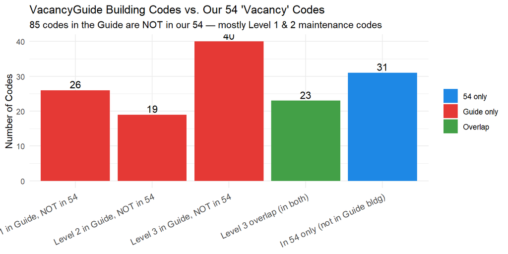

```r
summary_df <- tribble(
  ~category, ~count, ~group,
  "Level 1 in Guide, NOT in 54",  sum(in_guide_not_54 %in% guide_level1), "Guide only",
  "Level 2 in Guide, NOT in 54",  sum(in_guide_not_54 %in% guide_level2), "Guide only",
  "Level 3 in Guide, NOT in 54",  sum(in_guide_not_54 %in% guide_level3), "Guide only",
  "Level 3 overlap (in both)",    length(overlap), "Overlap",
  "In 54 only (not in Guide bldg)", length(in_54_not_guide), "54 only"
)

summary_df %>%
  mutate(category = fct_inorder(category)) %>%
  ggplot(aes(x = category, y = count, fill = group)) +
  geom_col() +
  geom_text(aes(label = count), vjust = -0.3, size = 4) +
  scale_fill_manual(values = c("Guide only" = "#E53935", "Overlap" = "#43A047", "54 only" = "#1E88E5")) +
  labs(title = "VacancyGuide Building Codes vs. Our 54 'Vacancy' Codes",
       subtitle = "85 codes in the Guide are NOT in our 54 — mostly Level 1 & 2 maintenance codes",
       x = NULL, y = "Number of Codes", fill = NULL) +
  theme_minimal() +
  theme(axis.text.x = element_text(angle = 25, hjust = 1, size = 10))
```

# 4. Correct Complete Tier Mapping

Now we build the **definitive reference table** that downstream feature engineering code will use. Every code gets its tier assignment directly from VacancyGuide.

```r
# Build the complete building tier mapping
building_tier_map <- bind_rows(
  tibble(code = guide_level1, guide_tier = "Level 1", guide_weight = 1L),
  tibble(code = guide_level2, guide_tier = "Level 2", guide_weight = 2L),
  tibble(code = guide_level3, guide_tier = "Level 3", guide_weight = 3L)
) %>%
  left_join(
    violation_def %>% select(violation_code, violation_code_title),
    by = c("code" = "violation_code")
  ) %>%
  mutate(
    in_our_54   = code %in% our_54,
    in_ovs_def  = code %in% c("9-3904", "9-3905", "PM15-901.1", "PM15-901.2", "PM15-301",
                                "CP-102", "CP-103", "PM-102.4/1", "PM-102.4/2",
                                "PM-102.4/3", "PM-102.4/4"),
    code_type = case_when(
      in_our_54 & in_ovs_def ~ "Vacancy code + OVS source",
      in_our_54              ~ "Vacancy code (not in OVS)",
      TRUE                   ~ "General maintenance code"
    )
  ) %>%
  arrange(guide_weight, code)

cat("=== Complete Building Tier Mapping ===\n")
```

```
## === Complete Building Tier Mapping ===
```

```r
cat("Total codes:", nrow(building_tier_map), "\n\n")
```

```
## Total codes: 108
```

```r
building_tier_map %>%
  count(guide_tier, code_type) %>%
  pivot_wider(names_from = code_type, values_from = n, values_fill = 0) %>%
  kable(caption = "Breakdown by tier and code type") %>%
  kable_styling(bootstrap_options = "striped", full_width = FALSE)
```

Breakdown by tier and code type

| guide_tier | General maintenance code | Vacancy code (not in OVS) | Vacancy code + OVS source |
| --- | --- | --- | --- |
| Level 1 | 26 | 0 | 0 |
| Level 2 | 19 | 0 | 0 |
| Level 3 | 40 | 16 | 7 |

### 4a. Full Level 1 Codes (+1 point)

```r
building_tier_map %>%
  filter(guide_weight == 1) %>%
  select(code, violation_code_title, code_type) %>%
  kable(col.names = c("Code", "Title", "Type"),
        caption = paste0("Level 1: ", sum(building_tier_map$guide_weight == 1),
                         " codes — Minor deterioration, may occur at occupied properties")) %>%
  kable_styling(bootstrap_options = c("striped", "condensed"), full_width = FALSE, font_size = 12)
```

Level 1: 26 codes — Minor deterioration, may occur at occupied properties

| Code | Title | Type |
| --- | --- | --- |
| PM-302.2/1 | EXT A-CLEAN/EXTERMINATE | General maintenance code |
| PM-302.2/2 | EXT A-CLEAN RUBBISH/GARBAGE | General maintenance code |
| PM-302.3/1 | EXT A-CLEAN WEEDS/PLANTS | General maintenance code |
| PM-302.4/6 | DRAINAGE-DOWNSPOUT CONNECT | General maintenance code |
| PM-302.4/7 | DRAINAGE-DOWNSPOUT REPR/REPLC | General maintenance code |
| PM-304.1/1 | EXT S-EXTERIOR REPAIR/MAINTAIN | General maintenance code |
| PM-304.6/1 | EXT S-CHIMMEYS/TOWERS MAINTAIN | General maintenance code |
| PM-304.8/1 | EXT S-WINDOW REPAIR/MAINTAIN | General maintenance code |
| PM-304.8/15 | EXT S-DOOR WEATHERTIGHT | General maintenance code |
| PM-304.8/16 | EXT S-WINDOW REPAIR/REPLACE | General maintenance code |
| PM-304.8/17 | EXT S-DOOR REPAIR/REPLACE | General maintenance code |
| PM-304.8/18 | EXT S-DOORFRAME REPAIR/REPLACE | General maintenance code |
| PM-304.8/19 | EXT S-WINDOW/FRAME RODENTPROOF | General maintenance code |
| PM-304.8/2 | EXT S-DOORS MAINTAIN | General maintenance code |
| PM-304.8/20 | EXT S-DOORS/FRAMES RODENTPROOF | General maintenance code |
| PM-304.8/21 | MIX USE PROP REPLAC W/D 80% | General maintenance code |
| PM15-304.10 | EXTERIOR STRUCTURE STAIRS, DECKS, PORCHES | General maintenance code |
| PM15-304.11 | EXTERIOR STRUCTURE CHIMNEYS TOWERS | General maintenance code |
| PM15-304.19 | DOOR AND WINDOW OCCUPIED/MIXED | General maintenance code |
| PM15-304.19O | DOOR AND WINDOW OCCUPIED/MIXED | General maintenance code |
| PM15-304.2 | EXTERIOR STRUCTURE PROTECTIVE TREATMENT | General maintenance code |
| PM15-304.8 | EXTERIOR STRUCTURE DECORATIVE FEATURES | General maintenance code |
| PM15-308.1 | RUBBISH & GARBAGE | General maintenance code |
| PM15-309.1 | PEST ELIMINATION INFESTATION | General maintenance code |
| PM15-309.3 | PEST ELIMINATION INFESTATION SINGLE OCCUPANT | General maintenance code |
| PM15-309.4 | PEST ELIMINATION INFESTATION | General maintenance code |

### 4b. Full Level 2 Codes (+2 points)

```r
building_tier_map %>%
  filter(guide_weight == 2) %>%
  select(code, violation_code_title, code_type) %>%
  kable(col.names = c("Code", "Title", "Type"),
        caption = paste0("Level 2: ", sum(building_tier_map$guide_weight == 2),
                         " codes — Moderate structural damage, stronger vacancy signal")) %>%
  kable_styling(bootstrap_options = c("striped", "condensed"), full_width = FALSE, font_size = 12)
```

Level 2: 19 codes — Moderate structural damage, stronger vacancy signal

| Code | Title | Type |
| --- | --- | --- |
| PM-304.2/1 | EXT S-FOUNDATION WALLS, MAINTA | General maintenance code |
| PM-304.3/1 | EXT S-WALLS REPAIR/MAINTAIN | General maintenance code |
| PM-304.3/2 | EXT S-WALLS MAKE WEATHERTIGHT | General maintenance code |
| PM-304.3/3 | EXT S-WALLS REPAIR BULGING | General maintenance code |
| PM-304.3/4 | EXT S-WALLS REPAIR CRACKS | General maintenance code |
| PM-304.3/5 | EXT S-WALLS REPAIR STUCCO | General maintenance code |
| PM-304.5/2 | EXT S-EXPOSED SURFACES MAINTAI | General maintenance code |
| PM-304.5/3 | EXT S-CORNICE BARGEBOARD DEFEC | General maintenance code |
| PM15-110.7 | ID WORK SCHEDULE REQ | General maintenance code |
| PM15-302.1 | EXTERIOR AREA SANITATION | General maintenance code |
| PM15-302.4 | EXTERIOR AREA WEEDS | General maintenance code |
| PM15-302.5 | EXTERIOR AREA RODENT HARBORAGE | General maintenance code |
| PM15-304.13 | EXTERIOR STRUCTURE WINDOWS, SKYLIGHTS DOOR FRAMES | General maintenance code |
| PM15-304.15 | EXTERIOR STRUCTURE DOORS | General maintenance code |
| PM15-304.16 | EXTERIOR STRUCTURE HATCHWAY | General maintenance code |
| PM15-304.4 | EXTERIOR STRUCTURE STRUCTURAL MEMBERS | General maintenance code |
| PM15-304.5 | EXTERIOR STRUCTURE FOUNDATIONS | General maintenance code |
| PM15-304.6 | EXTERIOR STRUCTURE WALLS | General maintenance code |
| PM15-304.7 | EXTERIOR STRUCTURE ROOF DRAINAGE | General maintenance code |

### 4c. Full Level 3 Codes (+3 points)

```r
building_tier_map %>%
  filter(guide_weight == 3) %>%
  select(code, violation_code_title, code_type) %>%
  kable(col.names = c("Code", "Title", "Type"),
        caption = paste0("Level 3: ", sum(building_tier_map$guide_weight == 3),
                         " codes — Severe: vacant, unsafe, unfit, or major collapse")) %>%
  kable_styling(bootstrap_options = c("striped", "condensed"), full_width = FALSE, font_size = 12)
```

Level 3: 63 codes — Severe: vacant, unsafe, unfit, or major collapse

| Code | Title | Type |
| --- | --- | --- |
| 9-3905 | VACANT STRUCTURE LICENSE | Vacancy code + OVS source |
| CP-103 | LICENSE - VACANT BUILDING | Vacancy code + OVS source |
| PM-102.4/2 | LICENSE-VAC RES BLDG | Vacancy code + OVS source |
| PM-102.4/4 | LICENSE-VAC COMM BLDG | Vacancy code + OVS source |
| PM-304.4/1 | EXT S-ROOF REPAIR | General maintenance code |
| PM-306.0/1 | VACANT PROP STANDARD | Vacancy code (not in OVS) |
| PM-306.0/90 | VACANT BLDG KEEP CLEAN GET LIC | Vacancy code (not in OVS) |
| PM-306.2/1 | VACANT BLDG UNSECURED COUNT | Vacancy code (not in OVS) |
| PM-306.2/4 | VAC PROP REPLAC WIN/DRS 80% | Vacancy code (not in OVS) |
| PM-306.2/90 | VACANT BLDG - VOTA | Vacancy code (not in OVS) |
| PM-306.2/91 | CP VAC PROP REPLAC WIN/DRS 80% | Vacancy code (not in OVS) |
| PM-306.2/92 | VAC PROP REPLAC WIN/DRS 80% CP | Vacancy code (not in OVS) |
| PM-307.1/1 | VACANT PROP UNSAFE | Vacancy code (not in OVS) |
| PM-307.1/11 | WALL DETERIORATED | General maintenance code |
| PM-307.1/12 | WALL PARTIALLY COLLAPSED | General maintenance code |
| PM-307.1/13 | WALL FIRE DAMAGED | General maintenance code |
| PM-307.1/19 | VACANT BLDG UNSEC/UNSAFE CSU | Vacancy code (not in OVS) |
| PM-307.1/2 | ROOF DETERIORATED | General maintenance code |
| PM-307.1/3 | ROOF PARTIALLY COLLAPSED | General maintenance code |
| PM-307.1/4 | ROOF FIRE DAMAGED | General maintenance code |
| PM-307.1/5 | F/C DETERIORATED | General maintenance code |
| PM-307.1/6 | FLOOR/CEILING PARTIALLY COLL | General maintenance code |
| PM-307.1/7 | FLOOR/CEILING FIRE DAMAGED | General maintenance code |
| PM-307.1/8 | WALL BULGED | General maintenance code |
| PM-307.1/9 | WALL FRACTURED | General maintenance code |
| PM-307.1/90 | VACANT BLDG - UNSAFE | Vacancy code (not in OVS) |
| PM-307.2/1 | VACANT PROP UNSAFE EQUIPMENT | Vacancy code (not in OVS) |
| PM-307.3/1 | UNFIT PROP STANDARD | General maintenance code |
| PM-307.3/2 | UNFIT PROP CEASED | General maintenance code |
| PM-307.3/90 | UNSAFE - UNFIT NO EVAC | Vacancy code (not in OVS) |
| PM-307.3/91 | UNSAFE - UNFIT RELOCATE | Vacancy code (not in OVS) |
| PM-308.1/1 | ROOF DETERIORATED ID | General maintenance code |
| PM-308.1/10 | WALL DETERIORATED IDF | General maintenance code |
| PM-308.1/11 | WALL PARTIALLY COLLAPSED ID | General maintenance code |
| PM-308.1/12 | WALL FIRE DAMAGED ID | General maintenance code |
| PM-308.1/2 | ROOF PARTIALLY COLLAPSED ID | General maintenance code |
| PM-308.1/3 | ROOF FIRE DAMAGED ID | General maintenance code |
| PM-308.1/4 | F/C DETERIORATED ID COLLAPSE | General maintenance code |
| PM-308.1/5 | FLOOR/CEILING PARTIALLY C ID | General maintenance code |
| PM-308.1/6 | FLOOR/CEILING FIRE DAMAGED ID | General maintenance code |
| PM-308.1/7 | WALL BULGED ID | General maintenance code |
| PM-308.1/8 | WALL CRACK/FRACT ID | General maintenance code |
| PM-308.1/9 | WALL LOOSE/MISS BRICKS ID | General maintenance code |
| PM15-108.1 | UNSAFE STRUCTURE | General maintenance code |
| PM15-108.2 | VACANT & OPEN | Vacancy code (not in OVS) |
| PM15-109.1 | UNFIT STRUCTURE | General maintenance code |
| PM15-110.1 | ID STRUCTURE | General maintenance code |
| PM15-301 | VACANT STRUCTURE & LAND | Vacancy code + OVS source |
| PM15-304.1 | GENERAL EXTERIOR VIOLATIONS | General maintenance code |
| PM15-304.19V | DOOR AND WINDOW VACANT | Vacancy code (not in OVS) |
| PM15-304.1A | EXTERIOR STRUCT UNSAFE COND 1 | General maintenance code |
| PM15-304.1B | EXTERIOR STRUCT UNSAFE COND 2 | General maintenance code |
| PM15-304.1C | EXTERIOR STRUCT UNSAFE COND 3 | General maintenance code |
| PM15-304.1D | EXTERIOR STRUCT UNSAFE COND 4 | General maintenance code |
| PM15-304.1E | EXTERIOR STRUCT UNSAFE COND 5 | General maintenance code |
| PM15-304.1F | EXTERIOR STRUCT UNSAFE COND 6 | General maintenance code |
| PM15-304.1G | EXTERIOR STRUCT UNSAFE COND 7 | General maintenance code |
| PM15-304.1H | EXTERIOR STRUCT UNSAFE COND 8 | General maintenance code |
| PM15-304.1I | EXTERIOR STRUCT UNSAFE COND 9 | General maintenance code |
| PM15-304.1J | EXTERIOR STRUCT UNSAFE COND 10 | General maintenance code |
| PM15-901.1 | VACANT & OPEN PROPERTIES | Vacancy code + OVS source |
| PM15-901.2 | VACANT PROPERTIES- BLIGHTED CONDITION | Vacancy code + OVS source |
| PM15-902.1 | LARGE VACANT PROPERTIES- OPENINGS IN GOOD REPAIR | Vacancy code (not in OVS) |

# 5. Vacant Land Codes (Separate Model)

For completeness, here are the land model violation codes (VacancyGuide p.5).

```r
land_tier_map <- tibble(code = guide_land, guide_weight = 1L) %>%
  left_join(
    violation_def %>% select(violation_code, violation_code_title),
    by = c("code" = "violation_code")
  ) %>%
  arrange(code)

land_tier_map %>%
  kable(col.names = c("Code", "Weight", "Title"),
        caption = paste0("Vacant Land: ", nrow(land_tier_map),
                         " codes — All weighted +1")) %>%
  kable_styling(bootstrap_options = c("striped", "condensed"), full_width = FALSE, font_size = 12)
```

Vacant Land: 9 codes — All weighted +1

| Code | Weight | Title |
| --- | --- | --- |
| CP-102 | 1 | LICENSE - VACANT LOT |
| PM-102.4/1 | 1 | LICENSE-VAC LOT |
| PM-102.4/3 | 1 | LICENSE-VAC WHARF/PIER |
| PM-302.2/4 | 1 | EXT A-VACANT LOT CLEAN/MAINTAI |
| PM-304.9/2 | 1 | PIER-VACANT FAULTY/NO BARRIER |
| PM-304.9/3 | 1 | PIER-VACANT POST SIGNS |
| PM-304.9/4 | 1 | PIER-VACANT OBTAIN LICENSE |
| PM-306.0/2 | 1 | VACANT LOT STANDARD |
| PM-306.0/91 | 1 | VACANT LOT KEEP CLEAN GET LIC |

# 6. Validation Against violations.csv

Now let’s check: how many of these codes actually appear in our violation data, and with what frequency?

```r
violations <- read_csv("../rawdata/violations.csv", show_col_types = FALSE) %>%
  janitor::clean_names()

# Count OPEN violations for each building tier code
building_viol_counts <- violations %>%
  filter(violationcode %in% building_all,
         tolower(violationstatus) == "open") %>%
  count(violationcode, name = "n_open") %>%
  right_join(building_tier_map %>% select(code, guide_tier, guide_weight),
             by = c("violationcode" = "code")) %>%
  replace_na(list(n_open = 0)) %>%
  arrange(guide_weight, desc(n_open))

cat("=== OPEN violations by tier ===\n")
```

```
## === OPEN violations by tier ===
```

```r
building_viol_counts %>%
  group_by(guide_tier) %>%
  summarise(
    n_codes_with_data = sum(n_open > 0),
    n_codes_total     = n(),
    total_open_viols  = sum(n_open),
    .groups = "drop"
  ) %>%
  kable(col.names = c("Tier", "Codes with ≥1 OPEN", "Total Codes", "Total OPEN Violations"),
        caption = "How many VacancyGuide codes actually have OPEN records in our data?") %>%
  kable_styling(bootstrap_options = "striped", full_width = FALSE)
```

How many VacancyGuide codes actually have OPEN records in our data?

| Tier | Codes with ≥1 OPEN | Total Codes | Total OPEN Violations |
| --- | --- | --- | --- |
| Level 1 | 9 | 26 | 5026 |
| Level 2 | 10 | 19 | 9942 |
| Level 3 | 22 | 63 | 12952 |

```r
building_viol_counts %>%
  filter(n_open > 0) %>%
  head(20) %>%
  kable(col.names = c("Code", "OPEN Count", "Tier", "Weight"),
        caption = "Top 20 building tier codes by OPEN violation count") %>%
  kable_styling(bootstrap_options = c("striped", "condensed"), full_width = FALSE, font_size = 12)
```

Top 20 building tier codes by OPEN violation count

| Code | OPEN Count | Tier | Weight |
| --- | --- | --- | --- |
| PM15-308.1 | 2352 | Level 1 | 1 |
| PM15-304.2 | 1262 | Level 1 | 1 |
| PM15-304.10 | 773 | Level 1 | 1 |
| PM15-304.8 | 464 | Level 1 | 1 |
| PM15-309.1 | 107 | Level 1 | 1 |
| PM15-309.4 | 49 | Level 1 | 1 |
| PM15-304.11 | 13 | Level 1 | 1 |
| PM15-304.19O | 4 | Level 1 | 1 |
| PM15-309.3 | 2 | Level 1 | 1 |
| PM15-302.4 | 4730 | Level 2 | 2 |
| PM15-302.1 | 2081 | Level 2 | 2 |
| PM15-304.7 | 1046 | Level 2 | 2 |
| PM15-304.13 | 917 | Level 2 | 2 |
| PM15-304.6 | 440 | Level 2 | 2 |
| PM15-304.15 | 415 | Level 2 | 2 |
| PM15-302.5 | 140 | Level 2 | 2 |
| PM15-304.4 | 83 | Level 2 | 2 |
| PM15-304.5 | 55 | Level 2 | 2 |
| PM15-304.16 | 35 | Level 2 | 2 |
| 9-3905 | 3404 | Level 3 | 3 |

### Codes with Zero OPEN Violations

```r
zero_codes <- building_viol_counts %>% filter(n_open == 0)

cat(nrow(zero_codes), "building tier codes have zero OPEN violations in current data.\n")
```

```
## 67 building tier codes have zero OPEN violations in current data.
```

```r
cat("These may be legacy codes or codes whose violations have all been resolved.\n\n")
```

```
## These may be legacy codes or codes whose violations have all been resolved.
```

```r
zero_codes %>%
  kable(col.names = c("Code", "OPEN Count", "Tier", "Weight")) %>%
  kable_styling(bootstrap_options = c("striped", "condensed"), full_width = FALSE, font_size = 12)
```

| Code | OPEN Count | Tier | Weight |
| --- | --- | --- | --- |
| PM-302.2/1 | 0 | Level 1 | 1 |
| PM-302.2/2 | 0 | Level 1 | 1 |
| PM-302.3/1 | 0 | Level 1 | 1 |
| PM-302.4/6 | 0 | Level 1 | 1 |
| PM-302.4/7 | 0 | Level 1 | 1 |
| PM-304.1/1 | 0 | Level 1 | 1 |
| PM-304.6/1 | 0 | Level 1 | 1 |
| PM-304.8/1 | 0 | Level 1 | 1 |
| PM-304.8/15 | 0 | Level 1 | 1 |
| PM-304.8/16 | 0 | Level 1 | 1 |
| PM-304.8/17 | 0 | Level 1 | 1 |
| PM-304.8/18 | 0 | Level 1 | 1 |
| PM-304.8/19 | 0 | Level 1 | 1 |
| PM-304.8/2 | 0 | Level 1 | 1 |
| PM-304.8/20 | 0 | Level 1 | 1 |
| PM-304.8/21 | 0 | Level 1 | 1 |
| PM15-304.19 | 0 | Level 1 | 1 |
| PM-304.2/1 | 0 | Level 2 | 2 |
| PM-304.3/1 | 0 | Level 2 | 2 |
| PM-304.3/2 | 0 | Level 2 | 2 |
| PM-304.3/3 | 0 | Level 2 | 2 |
| PM-304.3/4 | 0 | Level 2 | 2 |
| PM-304.3/5 | 0 | Level 2 | 2 |
| PM-304.5/2 | 0 | Level 2 | 2 |
| PM-304.5/3 | 0 | Level 2 | 2 |
| PM15-110.7 | 0 | Level 2 | 2 |
| CP-103 | 0 | Level 3 | 3 |
| PM-102.4/2 | 0 | Level 3 | 3 |
| PM-102.4/4 | 0 | Level 3 | 3 |
| PM-304.4/1 | 0 | Level 3 | 3 |
| PM-306.0/1 | 0 | Level 3 | 3 |
| PM-306.2/1 | 0 | Level 3 | 3 |
| PM-306.2/4 | 0 | Level 3 | 3 |
| PM-306.2/90 | 0 | Level 3 | 3 |
| PM-306.2/91 | 0 | Level 3 | 3 |
| PM-306.2/92 | 0 | Level 3 | 3 |
| PM-307.1/1 | 0 | Level 3 | 3 |
| PM-307.1/11 | 0 | Level 3 | 3 |
| PM-307.1/12 | 0 | Level 3 | 3 |
| PM-307.1/13 | 0 | Level 3 | 3 |
| PM-307.1/19 | 0 | Level 3 | 3 |
| PM-307.1/2 | 0 | Level 3 | 3 |
| PM-307.1/3 | 0 | Level 3 | 3 |
| PM-307.1/4 | 0 | Level 3 | 3 |
| PM-307.1/5 | 0 | Level 3 | 3 |
| PM-307.1/6 | 0 | Level 3 | 3 |
| PM-307.1/7 | 0 | Level 3 | 3 |
| PM-307.1/8 | 0 | Level 3 | 3 |
| PM-307.1/9 | 0 | Level 3 | 3 |
| PM-307.1/90 | 0 | Level 3 | 3 |
| PM-307.2/1 | 0 | Level 3 | 3 |
| PM-307.3/1 | 0 | Level 3 | 3 |
| PM-307.3/2 | 0 | Level 3 | 3 |
| PM-307.3/90 | 0 | Level 3 | 3 |
| PM-307.3/91 | 0 | Level 3 | 3 |
| PM-308.1/1 | 0 | Level 3 | 3 |
| PM-308.1/10 | 0 | Level 3 | 3 |
| PM-308.1/11 | 0 | Level 3 | 3 |
| PM-308.1/12 | 0 | Level 3 | 3 |
| PM-308.1/2 | 0 | Level 3 | 3 |
| PM-308.1/3 | 0 | Level 3 | 3 |
| PM-308.1/4 | 0 | Level 3 | 3 |
| PM-308.1/5 | 0 | Level 3 | 3 |
| PM-308.1/6 | 0 | Level 3 | 3 |
| PM-308.1/7 | 0 | Level 3 | 3 |
| PM-308.1/8 | 0 | Level 3 | 3 |
| PM-308.1/9 | 0 | Level 3 | 3 |

# 7. Feature Engineering Implications

### Methodological concern: avoid importing external bias

The VacancyGuide tier system (Level 1/2/3) was constructed through expert judgment and trial-and-error, not statistical analysis (confirmed by Tim Haynes at the Jan 27 kickoff meeting). Using these predetermined tiers directly as ML features risks:

1. **Importing subjective bias** — the tier assignments reflect someone else’s assumptions about which violations matter more, without empirical validation.
2. **Collinearity** — tier-based features are derived from the same underlying violation codes, so `max_violation_tier`, `has_level2`, and `n_violations_L2` will be mechanically correlated.
3. **Information loss** — collapsing 108 codes into 3 tiers discards variation that the ML model could learn from.

Per instructor feedback (Prof. Fichman, Feb 18 2026): feature engineering should start from **raw violation data** and use **univariate correlation analysis** to determine which features are genuinely predictive, rather than assuming the city’s groupings are correct.

### Recommended approach: raw features first, tiers as comparison

**Track A (Primary): Raw violation features — let the model learn**

Built directly from violations.csv without imposing any external grouping.

| Feature | Logic |
| --- | --- |
| `n_violations_total` | Count of ALL violations on the property (any code) |
| `n_violations_open` | Count of currently OPEN violations |
| `n_violation_codes_distinct` | Number of distinct violation codes on the property |
| `oldest_open_violation_days` | Days since the oldest OPEN violation |
| `newest_violation_days` | Days since the most recent violation |
| `has_vacancy_code` | Binary: any of the 54 vacancy keyword codes present |
| `has_structural_code` | Binary: any PM15-304.x / PM-307.x structural codes present |
| `has_unsafe_code` | Binary: PM15-108.1 (Unsafe) or PM15-108.2 (Vacant & Open) present |
| `has_fire_code` | Binary: any F-xxx / FC-xxx fire safety codes present |
| `n_vacancy_violations` | Count of violations with vacancy keyword codes |

These features preserve the full variation in the data. The ML model determines which violation patterns are most predictive of OVS — we do not pre-impose weights.

**Track B (Comparison): VacancyGuide tier features — for benchmarking**

Uses the 108-code tier mapping from this document. These features are included **only to compare against Track A** and to evaluate whether the city’s existing groupings add predictive value beyond raw features.

[output not shown]

**Track C (Validation): Univariate correlation analysis**

Before any modeling, we will:

1. Compute correlation of each Track A and Track B feature with OVS
2. Build a feature-to-feature correlation heatmap to identify collinearity
3. Create facet plots of continuous features split by OVS (0 vs 1)
4. Use these results to decide which features enter the model and whether tier-based groupings are empirically justified

This ensures we are not importing the city’s heuristic assumptions as ground truth, while still being able to evaluate whether their expert judgment aligns with the data.

# 8. Non-Violation Indicators from VacancyGuide

For completeness, here are the other building model indicators from VacancyGuide (pages 6–7) that are NOT violation-based:

```r
tribble(
  ~indicator, ~source, ~weight, ~data_status,
  "Water: NB9 (Vacant) installation status, excl. type 24", "Water Revenue", "+1", "Pending legal",
  "Water: No usage 4+ months (excl. NB3/NB9/NB2/NB8/type24/fire/commercial/stormwater)", "Water Revenue", "+1", "Pending legal",
  "PWD: Side yard exemption for stormwater billing", "PWD", "Reset to 0", "Pending legal",
  "Permit: completed in last 4 years (plumbing/demolition/electrical/fire suppression/mechanical/building new construction/alteration)", "L+I Permits", "-1", "To download",
  "License: Active rental license (revenuecode = 3202)", "Business Licenses", "-1", "Available",
  "License: Active vacancy license (revenuecode IN 3219, 3634)", "Business Licenses", "+2", "Available",
  "Permit: Completed demolition without subsequent new construction", "L+I Permits", "Reset to 0", "To download"
) %>%
  kable(col.names = c("Indicator", "Source", "Weight", "Data Status"),
        caption = "Non-violation building indicators from VacancyGuide") %>%
  kable_styling(bootstrap_options = c("striped", "condensed"), full_width = FALSE, font_size = 12)
```

Non-violation building indicators from VacancyGuide

| Indicator | Source | Weight | Data Status |
| --- | --- | --- | --- |
| Water: NB9 (Vacant) installation status, excl. type 24 | Water Revenue | +1 | Pending legal |
| Water: No usage 4+ months (excl. NB3/NB9/NB2/NB8/type24/fire/commercial/stormwater) | Water Revenue | +1 | Pending legal |
| PWD: Side yard exemption for stormwater billing | PWD | Reset to 0 | Pending legal |
| Permit: completed in last 4 years (plumbing/demolition/electrical/fire suppression/mechanical/building new construction/alteration) | L+I Permits | -1 | To download |
| License: Active rental license (revenuecode = 3202) | Business Licenses | -1 | Available |
| License: Active vacancy license (revenuecode IN 3219, 3634) | Business Licenses | +2 | Available |
| Permit: Completed demolition without subsequent new construction | L+I Permits | Reset to 0 | To download |

# 9. Corrections to Previous Work

# 10. Export Reference Tables

Save the tier mapping as CSV for use in downstream Rmd files.

```r
# Ensure output directory exists
dir.create("../data", showWarnings = FALSE, recursive = TRUE)

# Building tier mapping
building_tier_map %>%
  select(code, guide_tier, guide_weight, violation_code_title, in_our_54, in_ovs_def) %>%
  write_csv("../data/building_tier_mapping.csv")

# Land codes
land_tier_map %>%
  write_csv("../data/land_violation_codes.csv")

# Our 54 vacancy codes (still useful as a separate reference)
tibble(code = our_54) %>%
  left_join(violation_def %>% select(violation_code, violation_code_title),
            by = c("code" = "violation_code")) %>%
  write_csv("../data/vacancy_keyword_codes_54.csv")

cat("Exported:\n")
```

```
## Exported:
```

```r
cat("  ../data/building_tier_mapping.csv (", nrow(building_tier_map), " rows)\n")
```

```
##   ../data/building_tier_mapping.csv ( 108  rows)
```

```r
cat("  ../data/land_violation_codes.csv  (", nrow(land_tier_map), " rows)\n")
```

```
##   ../data/land_violation_codes.csv  ( 9  rows)
```

```r
cat("  ../data/vacancy_keyword_codes_54.csv (", length(our_54), " rows)\n")
```

```
##   ../data/vacancy_keyword_codes_54.csv ( 54  rows)
```

# References

- **VacancyGuide2026.pdf** — “Vacant Property Indicators Model,” updated 2/3/2026, received from Taylor Popp via email on Feb 5, 2026. Pages 6–7 contain the building model SQL queries; page 5 contains the land model queries; pages 8–10 contain the reference violation code table.
- **VIOLATION_DEFINITION.csv** — L+I violation code lookup table, downloaded from OpenDataPhilly (L+I Code Violations attachment).
- **Kickoff meeting notes** (Jan 27, 2026) — Tim Haynes confirmed: “only the most severe violation is scored per property”; weights were set through trial and error.